# Technical Assessment - Prerak Shah slides

```python
# Importing Libraries
import pandas as pd
import numpy as np
import datetime
import seaborn as sns
import matplotlib.pyplot as plt

# Import the relevant modules for MMM Modeling
import jax.numpy as jnp
import numpyro
from lightweight_mmm import lightweight_mmm
from lightweight_mmm import optimize_media
from lightweight_mmm import plot
from lightweight_mmm import preprocessing
from lightweight_mmm import utils
from sklearn.metrics import mean_absolute_percentage_error
```

```python
# Reading data files
campaign_data_p1 = pd.read_excel('Technical Assesment - Data Scientist.xlsx',sheet_name="1")
campaign_data_p2 = pd.read_excel('Technical Assesment - Data Scientist.xlsx',sheet_name="2",usecols='A:G')
campaign_data_p3 = pd.read_excel('Technical Assesment - Data Scientist.xlsx',sheet_name="3",usecols='A:D')
```

### Problem 1

- A branding campaign was executed only in city A from **2022-03-12 to 2022-04-10**.
- How many additional users were generated by the campaign?
- Please, explain the assumption(s) and the logic of your answer.

```python
# Assumptions:
# 1. Product was introduce/launched both in City A & B from Jan 1st, 2022.
# 2. In data we see an increase of # of users for city A, when a campaign was executed on March 12, 2022
campaign_data_p1.info()
```

```
<class 'pandas.core.frame.DataFrame'>
RangeIndex: 100 entries, 0 to 99
Data columns (total 3 columns):
 #   Column                  Non-Null Count  Dtype
---  ------                  --------------  -----
 0   DATE                    100 non-null    datetime64[ns]
 1   NUMBER_OF_USERS_CITY_A  100 non-null    int64
 2   NUMBER_OF_USERS_CITY_B  100 non-null    int64
dtypes: datetime64[ns](1), int64(2)
memory usage: 2.5 KB
```

```python
#Creating new cols for week numbers and percent change to identify the campaign effect
campaign_data_p1 = campaign_data_p1.drop(['NUMBER_OF_USERS_CITY_B'],axis=1)
campaign_data_p1['weeknumber'] = campaign_data_p1['DATE'].dt.strftime('%U')
campaign_data_p1['pct_change'] = campaign_data_p1.groupby(['weeknumber'])['NUMBER_OF_USERS_CITY_A'].pct_change()
```

```python
# From this we can see that there is a 5% increase in # of users in the week after campaign executed.
# However, later it drops and stays close to 0% change.
campaign_a_trend = campaign_data_p1.groupby(['DATE','weeknumber'])['NUMBER_OF_USERS_CITY_A'].mean()
campaign_a_trend = pd.DataFrame(campaign_a_trend)
campaign_a_trend
```

| DATE | weeknumber | NUMBER_OF_USERS_CITY_A |
| --- | --- | --- |
| 2022-01-01 | 00 | 105.0 |
| 2022-01-02 | 01 | 106.0 |
| 2022-01-03 | 01 | 107.0 |
| 2022-01-04 | 01 | 106.0 |
| 2022-01-05 | 01 | 101.0 |
| ... | ... | ... |
| 2022-04-06 | 14 | 115.0 |
| 2022-04-07 | 14 | 117.0 |
| 2022-04-08 | 14 | 113.0 |
| 2022-04-09 | 14 | 111.0 |
| 2022-04-10 | 15 | 114.0 |

100 rows × 1 columns

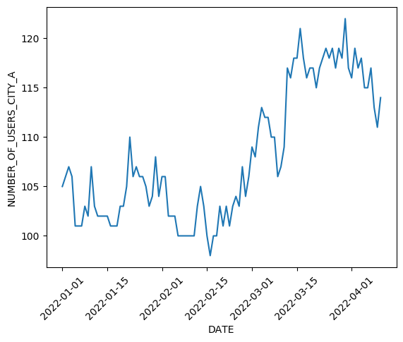

```python
#Visualizing the avg users per day
ax = sns.lineplot(x='DATE',y='NUMBER_OF_USERS_CITY_A',data=campaign_a_trend)
plt.xticks(rotation=45)
#ax.axvspan('2022-03-12','2022-04-10',color='g',alpha=0.1)
```

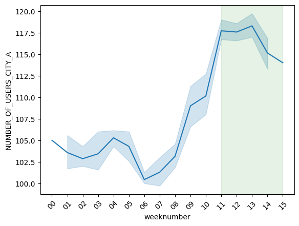

```python
#Visualizing the avg users per week
ax = sns.lineplot(x='weeknumber',y='NUMBER_OF_USERS_CITY_A',data=campaign_a_trend)
plt.xticks(rotation=45)
ax.axvspan('11','15',color='g',alpha=0.1)
```

```python
#Splitting data before and after campaign
before_campaign = campaign_data_p1[campaign_data_p1['DATE']<'2022-03-12']
after_campaign = campaign_data_p1[campaign_data_p1['DATE']>='2022-03-12']
```

```python
#Getting avg by week before campaign started
before_campaign_avg = before_campaign.groupby(['weeknumber'])['NUMBER_OF_USERS_CITY_A'].mean()
before_campaign_avg = pd.DataFrame(before_campaign_avg)
before_campaign_avg
```

| weeknumber | NUMBER_OF_USERS_CITY_A |
| --- | --- |
| 00 | 105.000000 |
| 01 | 103.571429 |
| 02 | 102.857143 |
| 03 | 103.428571 |
| 04 | 105.285714 |
| 05 | 104.285714 |
| 06 | 100.428571 |
| 07 | 101.285714 |
| 08 | 103.142857 |
| 09 | 109.000000 |
| 10 | 109.000000 |

```python
#Getting avg by week after campaign executed
after_campaign_avg = after_campaign.groupby(['weeknumber'])['NUMBER_OF_USERS_CITY_A'].mean()
after_campaign_avg = pd.DataFrame(after_campaign_avg)
after_campaign_avg
```

| weeknumber | NUMBER_OF_USERS_CITY_A |
| --- | --- |
| 10 | 117.000000 |
| 11 | 117.714286 |
| 12 | 117.571429 |
| 13 | 118.285714 |
| 14 | 115.142857 |
| 15 | 114.000000 |

```python
#Results: Shows the avg # of users increased over time because of the campaign introduced in city A
print("Avg # of users before campaign: {}".format(round(before_campaign_avg['NUMBER_OF_USERS_CITY_A'].mean())))
print("Avg # of users after campaign: {}".format(round(after_campaign_avg['NUMBER_OF_USERS_CITY_A'].mean())))
print("Avg # of increase in users after introducing branding campaign: {}".format(round(after_campaign_avg['NUMBER_OF_USERS_CITY_A'].mean()-before_campaign_avg['NUMBER_OF_USERS_CITY_A'].mean())))
```

```
Avg # of users before campaign: 104
Avg # of users after campaign: 117
Avg # of increase in users after introducing branding campaign: 12
```

### Problem 2

- Online ads campaigns are usually organized by Campaign, Ad Group (or Ad Set), and Ads.
- A campaign can have many ad groups that target different groups of people. Then, inside each ad group, you have the ads that people in that group will see.
- Before running, you never know which campaign or ad group will be the best. It’s normal to launch multiple ad groups and after a few days turn off the ones that are not reaching your goals.
- The problem is that without attribution you don’t know which ad groups to turn off and which to allocate more budget to.

  ```
    - Could you quantify the effects of the different Ad Groups?
    - How would you distribute your budget among the different ad groups?
  ```

- Please, provide details about the following topics to be used in the model:
  - Frequency Selected (Daily, Weekly, or Monthly)
  - Variables to use as Media Data (inputs)
  - Criteria used to split between training and validation
  - Variable Transformations

```python
#Removing this Ad group as there is no spend allocated to it
campaign_data_p2 = campaign_data_p2[campaign_data_p2['Ad group']!='Brand 1 Ad Group 12']
```

```python
# Getting Total Spend by ad groups to calculate the ROI
total_spend_adgroup = pd.DataFrame(campaign_data_p2.groupby(['Ad group'])[['Spend','Users (Target)']].sum()).rename(
columns = {'Spend': 'Total_spend', 'Users (Target)':'Total_users'}
).reset_index()
total_spend_adgroup.head()
```

|  | Ad group | Total_spend | Total_users |
| --- | --- | --- | --- |
| 0 | Brand 1 Ad Group 1 | 2073.30 | 4288463.0 |
| 1 | Brand 1 Ad Group 10 | 25.34 | 49588.0 |
| 2 | Brand 1 Ad Group 11 | 14228.58 | 12084928.0 |
| 3 | Brand 1 Ad Group 13 | 2971.30 | 3657799.0 |
| 4 | Brand 1 Ad Group 14 | 706.42 | 1310698.0 |
| 5 | Brand 1 Ad Group 2 | 8495.99 | 14758871.0 |
| 6 | Brand 1 Ad Group 3 | 607.61 | 598640.0 |
| 7 | Brand 1 Ad Group 4 | 38449.73 | 21761505.0 |
| 8 | Brand 1 Ad Group 5 | 170.20 | 315189.0 |
| 9 | Brand 1 Ad Group 6 | 291.55 | 414766.0 |
| 10 | Brand 1 Ad Group 7 | 471.71 | 1139952.0 |
| 11 | Brand 1 Ad Group 8 | 280.53 | 606847.0 |
| 12 | Brand 1 Ad Group 9 | 5623.99 | 4241190.0 |
| 13 | Brand 2 Ad Group 1 | 52654.71 | 80874910.0 |
| 14 | Brand 2 Ad Group 2 | 77147.69 | 84891633.0 |
| 15 | Brand 2 Ad Group 3 | 13292.43 | 17707231.0 |
| 16 | Brand 2 Ad Group 4 | 2733.77 | 4017400.0 |
| 17 | Brand 2 Ad Group 5 | 2382.50 | 1313546.0 |
| 18 | Brand 2 Ad Group 6 | 10.45 | 0.0 |

```python
#Joining with main df to get total spend by line item
campaign_data_p2 = campaign_data_p2.merge(total_spend_adgroup, how='left',on='Ad group')
campaign_data_p2
```

|  | Date | Brand Alias | Ad group | Impressions | Clicks | Spend | Users (Target) | Total_spend | Total_users |
| --- | --- | --- | --- | --- | --- | --- | --- | --- | --- |
| 0 | 2021-10-17 | Brand 1 | Brand 1 Ad Group 1 | 2862 | 28 | 4.86 | 21495.0 | 2073.30 | 4288463.0 |
| 1 | 2021-10-17 | Brand 1 | Brand 1 Ad Group 1 | 455 | 20 | 5.79 | 23994.0 | 2073.30 | 4288463.0 |
| 2 | 2021-10-17 | Brand 1 | Brand 1 Ad Group 10 | 33 | 0 | 0.00 | 0.0 | 25.34 | 49588.0 |
| 3 | 2021-10-17 | Brand 1 | Brand 1 Ad Group 11 | 0 | 0 | 0.00 | 0.0 | 14228.58 | 12084928.0 |
| 4 | 2021-10-17 | Brand 1 | Brand 1 Ad Group 11 | 0 | 0 | 0.00 | 0.0 | 14228.58 | 12084928.0 |
| ... | ... | ... | ... | ... | ... | ... | ... | ... | ... |
| 9577 | 2022-01-11 | Brand 2 | Brand 2 Ad Group 2 | 4639 | 10 | 7.36 | 0.0 | 77147.69 | 84891633.0 |
| 9578 | 2022-01-11 | Brand 2 | Brand 2 Ad Group 3 | 15336 | 49 | 33.79 | 63874.0 | 13292.43 | 17707231.0 |
| 9579 | 2022-01-11 | Brand 2 | Brand 2 Ad Group 3 | 4811 | 6 | 3.66 | 0.0 | 13292.43 | 17707231.0 |
| 9580 | 2022-01-11 | Brand 2 | Brand 2 Ad Group 3 | 22838 | 36 | 19.57 | 29495.0 | 13292.43 | 17707231.0 |
| 9581 | 2022-01-11 | Brand 2 | Brand 2 Ad Group 5 | 1826 | 3 | 1.99 | 87643.0 | 2382.50 | 1313546.0 |

9582 rows × 9 columns

```python
# CTR: Click through rate
# CPC: Cost per Click
# CPM: Cost per thousand impression
# ROI: Return on Investment
campaign_data_p2['CTR'] = campaign_data_p2['Clicks']/campaign_data_p2['Impressions']
campaign_data_p2['CPC'] = campaign_data_p2['Spend']/campaign_data_p2['Clicks']
campaign_data_p2['CPM'] = (campaign_data_p2['Spend']/campaign_data_p2['Impressions'])*1000
campaign_data_p2['ROI'] = campaign_data_p2['Spend']/campaign_data_p2['Total_spend']
campaign_data_p2.head()
```

|  | Date | Brand Alias | Ad group | Impressions | Clicks | Spend | Users (Target) | Total_spend | Total_users | CTR | CPC | CPM | ROI |
| --- | --- | --- | --- | --- | --- | --- | --- | --- | --- | --- | --- | --- | --- |
| 0 | 2021-10-17 | Brand 1 | Brand 1 Ad Group 1 | 2862 | 28 | 4.86 | 21495.0 | 2073.30 | 4288463.0 | 0.009783 | 0.173571 | 1.698113 | 0.002344 |
| 1 | 2021-10-17 | Brand 1 | Brand 1 Ad Group 1 | 455 | 20 | 5.79 | 23994.0 | 2073.30 | 4288463.0 | 0.043956 | 0.289500 | 12.725275 | 0.002793 |
| 2 | 2021-10-17 | Brand 1 | Brand 1 Ad Group 10 | 33 | 0 | 0.00 | 0.0 | 25.34 | 49588.0 | 0.000000 | NaN | 0.000000 | 0.000000 |
| 3 | 2021-10-17 | Brand 1 | Brand 1 Ad Group 11 | 0 | 0 | 0.00 | 0.0 | 14228.58 | 12084928.0 | NaN | NaN | NaN | 0.000000 |
| 4 | 2021-10-17 | Brand 1 | Brand 1 Ad Group 11 | 0 | 0 | 0.00 | 0.0 | 14228.58 | 12084928.0 | NaN | NaN | NaN | 0.000000 |

```python
# Adding Granularity in Dates
days = {0:'Mon',1:'Tues',2:'Weds',3:'Thurs',4:'Fri',5:'Sat',6:'Sun'}
month = {1:'Jan',10:'Oct',11:'Nov',12:'Dec'}
campaign_data_p2['day_of_week'] = campaign_data_p2['Date'].dt.dayofweek
campaign_data_p2['day_of_week'] = campaign_data_p2['day_of_week'].apply(lambda x: days[x])
campaign_data_p2['Week_num'] = campaign_data_p2['Date'].dt.isocalendar().week
campaign_data_p2['year'] = pd.DatetimeIndex(campaign_data_p2['Date']).year
campaign_data_p2['month'] = pd.DatetimeIndex(campaign_data_p2['Date']).month
campaign_data_p2['month'] = campaign_data_p2['month'].apply(lambda x: month[x])
campaign_data_p2.head()
```

|  | Date | Brand Alias | Ad group | Impressions | Clicks | Spend | Users (Target) | Total_spend | Total_users | CTR | CPC | CPM | ROI | day_of_week | Week_num | year | month |
| --- | --- | --- | --- | --- | --- | --- | --- | --- | --- | --- | --- | --- | --- | --- | --- | --- | --- |
| 0 | 2021-10-17 | Brand 1 | Brand 1 Ad Group 1 | 2862 | 28 | 4.86 | 21495.0 | 2073.30 | 4288463.0 | 0.009783 | 0.173571 | 1.698113 | 0.002344 | Sun | 41 | 2021 | Oct |
| 1 | 2021-10-17 | Brand 1 | Brand 1 Ad Group 1 | 455 | 20 | 5.79 | 23994.0 | 2073.30 | 4288463.0 | 0.043956 | 0.289500 | 12.725275 | 0.002793 | Sun | 41 | 2021 | Oct |
| 2 | 2021-10-17 | Brand 1 | Brand 1 Ad Group 10 | 33 | 0 | 0.00 | 0.0 | 25.34 | 49588.0 | 0.000000 | NaN | 0.000000 | 0.000000 | Sun | 41 | 2021 | Oct |
| 3 | 2021-10-17 | Brand 1 | Brand 1 Ad Group 11 | 0 | 0 | 0.00 | 0.0 | 14228.58 | 12084928.0 | NaN | NaN | NaN | 0.000000 | Sun | 41 | 2021 | Oct |
| 4 | 2021-10-17 | Brand 1 | Brand 1 Ad Group 11 | 0 | 0 | 0.00 | 0.0 | 14228.58 | 12084928.0 | NaN | NaN | NaN | 0.000000 | Sun | 41 | 2021 | Oct |

```python
campaign_budget_opt2 = campaign_data_p2.groupby(['Brand Alias','Ad group','Date','month','day_of_week']).agg({
    'Impressions':'sum',
    'Clicks':'sum',
    'Spend':'sum',
    'CTR':'sum',
    'CPC':'sum',
    'CPM':'sum',
    'Total_spend':'min',
    'ROI':'sum',
    'Users (Target)':'sum'
}).reset_index().sort_values(by='Date',ascending=True)

campaign_budget_opt2
```

|  | Brand Alias | Ad group | Date | month | day_of_week | Impressions | Clicks | Spend | CTR | CPC | CPM | Total_spend | ROI | Users (Target) |
| --- | --- | --- | --- | --- | --- | --- | --- | --- | --- | --- | --- | --- | --- | --- |
| 0 | Brand 1 | Brand 1 Ad Group 1 | 2021-10-17 | Oct | Sun | 3317 | 48 | 10.65 | 0.053739 | 0.463071 | 14.423388 | 2073.30 | 0.005137 | 45489.0 |
| 729 | Brand 1 | Brand 1 Ad Group 7 | 2021-10-17 | Oct | Sun | 1054 | 15 | 3.83 | 0.062869 | 0.720000 | 17.397164 | 471.71 | 0.008119 | 3499.0 |
| 642 | Brand 1 | Brand 1 Ad Group 6 | 2021-10-17 | Oct | Sun | 94 | 2 | 1.10 | 0.021277 | 0.550000 | 11.702128 | 291.55 | 0.003773 | 0.0 |
| 559 | Brand 1 | Brand 1 Ad Group 5 | 2021-10-17 | Oct | Sun | 55 | 10 | 3.64 | 0.295666 | 0.982222 | 116.919505 | 170.20 | 0.021387 | 7997.0 |
| 816 | Brand 1 | Brand 1 Ad Group 8 | 2021-10-17 | Oct | Sun | 248 | 4 | 1.30 | 0.030398 | 0.546667 | 9.443589 | 280.53 | 0.004634 | 3749.0 |
| ... | ... | ... | ... | ... | ... | ... | ... | ... | ... | ... | ... | ... | ... | ... |
| 1305 | Brand 2 | Brand 2 Ad Group 4 | 2022-01-11 | Jan | Tues | 33431 | 76 | 41.03 | 0.002273 | 0.539868 | 1.227304 | 2733.77 | 0.015009 | 17790.0 |
| 214 | Brand 1 | Brand 1 Ad Group 11 | 2022-01-11 | Jan | Tues | 16126 | 162 | 47.15 | 0.028675 | 1.034345 | 9.412372 | 14228.58 | 0.003314 | 72487.0 |
| 127 | Brand 1 | Brand 1 Ad Group 10 | 2022-01-11 | Jan | Tues | 19 | 1 | 0.12 | 0.052632 | 0.120000 | 6.315789 | 25.34 | 0.004736 | 0.0 |
| 641 | Brand 1 | Brand 1 Ad Group 5 | 2022-01-11 | Jan | Tues | 171 | 10 | 3.36 | 0.095998 | 0.800000 | 35.719424 | 170.20 | 0.019741 | 12246.0 |
| 1250 | Brand 2 | Brand 2 Ad Group 3 | 2022-01-11 | Jan | Tues | 56667 | 117 | 74.26 | 0.013508 | 4.166536 | 9.537022 | 13292.43 | 0.005587 | 123556.0 |

1411 rows × 14 columns

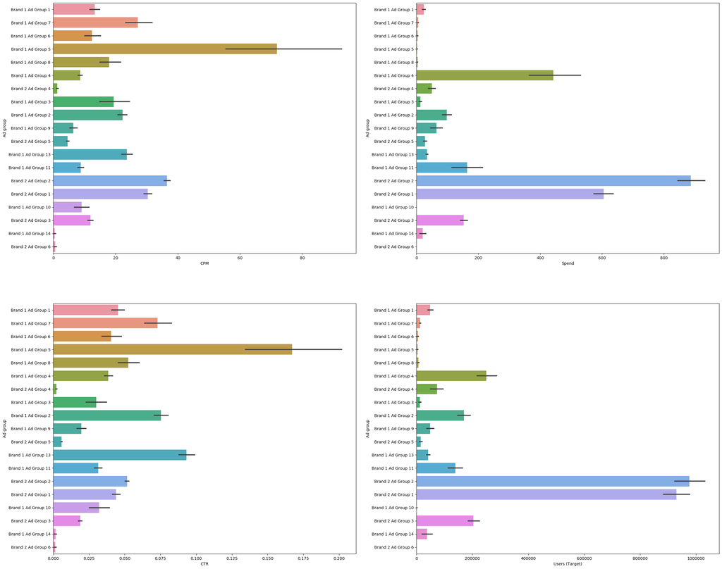

```python
figure, axis = plt.subplots(2, 2,figsize=(30,25))
sns.barplot(x='CPM',y='Ad group', data=campaign_budget_opt2,ax=axis[0,0])
ax = sns.barplot(x='CTR',y='Ad group', data=campaign_budget_opt2,ax=axis[1,0])
ax = sns.barplot(x='Users (Target)',y='Ad group', data=campaign_budget_opt2,ax=axis[1,1])
ax = sns.barplot(x='Spend',y='Ad group', data=campaign_budget_opt2,ax=axis[0,1])
```

#### Conclusion

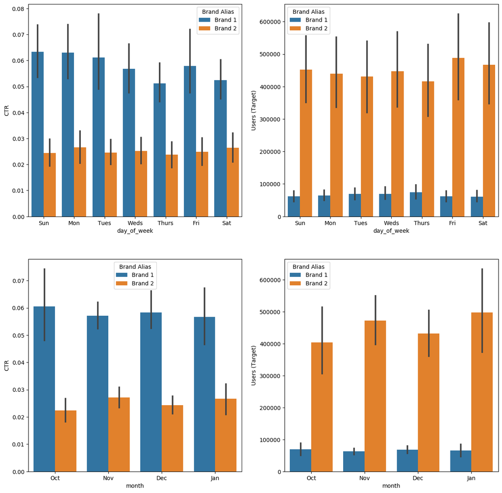

```python
figure, axis = plt.subplots(2, 2,figsize=(15,15))
sns.barplot(x='day_of_week',y='CTR',hue='Brand Alias', data=campaign_budget_opt2,ax=axis[0,0])
sns.barplot(x='day_of_week',y='Users (Target)',hue='Brand Alias', data=campaign_budget_opt2,ax=axis[0,1])
sns.barplot(x='month',y='CTR',hue='Brand Alias', data=campaign_budget_opt2,ax=axis[1,0])
sns.barplot(x='month',y='Users (Target)',hue='Brand Alias', data=campaign_budget_opt2,ax=axis[1,1])
```

#### Preparing Data for MMM Modeling

```python
SEED = 101
```

```python
campaign_budget_opt = campaign_data_p2.groupby(["Date", "Ad group"])[["Impressions","CPC","Users (Target)"]].sum()
```

```python
#Pre-processing Inputs into:
# 1. each row corresponded to a day
# 2. each column was the number of impressions for an ad group
media_data_raw = campaign_budget_opt['Impressions'].unstack().fillna(0)
costs_raw = campaign_budget_opt['CPC'].unstack()
roi_raw = campaign_budget_opt['Users (Target)'].reset_index().groupby(["Date"]).sum()
```

#### Train & Test Split for Model Validations

```python
#I used a simple validation split by time.
#I selected the last 28 days as validation

split_point = pd.Timestamp("2021-12-15") # 28 days to end of data

media_data_train = media_data_raw.loc[:split_point - pd.Timedelta(1,'D')]
media_data_test = media_data_raw.loc[split_point:]

target_train = roi_raw.loc[:split_point - pd.Timedelta(1,'D')]
target_test = roi_raw.loc[split_point:]

costs_train = costs_raw.loc[:split_point - pd.Timedelta(1,'D')].sum(axis=0).loc[media_data_train.columns]

#Using organic data as extra features can give you a more accurate view of your paid media effects.
organic_raw = pd.DataFrame({'organic_search': 0, 'organic_social': 0}, index=media_data_raw.index)
organic_raw['organic_search'] = roi_raw.values/10 + np.random.randint(10000, 100000, organic_raw.shape[0])
organic_raw['organic_social'] = roi_raw.values/10 + np.random.randint(10000, 100000, organic_raw.shape[0])

organic_data_train = organic_raw.loc[:split_point - pd.Timedelta(1,'D')]
organic_data_test = organic_raw.loc[split_point:]
```

```python
# Transforming CustomScalar on Data for MMM Model
media_scaler = preprocessing.CustomScaler(divide_operation=jnp.mean)
organic_scaler = preprocessing.CustomScaler(divide_operation=jnp.mean)
target_scaler = preprocessing.CustomScaler(divide_operation=jnp.mean)
cost_scaler = preprocessing.CustomScaler(divide_operation=jnp.mean)

media_data_train_scaled = media_scaler.fit_transform(media_data_train.values)
organic_data_train_scaled = organic_scaler.fit_transform(organic_data_train.values)

target_train_scaled = target_scaler.fit_transform(target_train.values.squeeze())
target_test_scaled = target_scaler.fit_transform(target_test.values.squeeze())
costs_scaled = cost_scaler.fit_transform(costs_train.values)

media_data_test_scaled = media_scaler.transform(media_data_test.values)
organic_data_test_scaled = organic_scaler.transform(organic_data_test.values)

media_names = media_data_raw.columns
```